# Series de Tiempo Económicas

v. 2026.03.09

PDF

## Introducción

## Estacionariedad (1/2)

Recordemos que una serie de tiempo, \(y_t\), es estacionaria si:

1. Su media es constante:

   \[ \begin{align} \mathbb{E}(y_t) &= \mu_{y_t} \\ & = \mu \end{align} \]
2. Su función de autocovarianza, \(Cov(y_t, y_{t-h})\), es tal que:

   \[ \begin{align} Cov(y_t, y_{t-h}) & = \gamma_y(h) \\ &= \gamma(h); \ \forall \ h \in \mathbb{Z} \end{align} \]

## Estacionariedad (2/2)

¿Cuáles de estas series de tiempo parecen estacionarias?

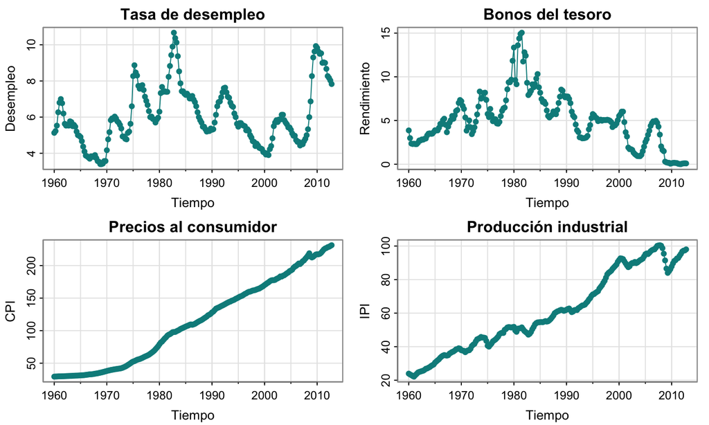

## Modelos estacionarios

Para modelar series de tiempo estacionarias usamos modelos **Autorregresivos con Promedios Móviles (ARMA)**. Estos combinan:

- *Parte autorregresiva, AR*: La serie se modela como una combinación lineal de sus valores pasados.
- *Parte de medias móviles, MA*: La serie se modela en función de sus errores pasados.

Los modelos ARMA nos permiten capturar la **parte cíclica** de una serie de tiempo, es decir, las fluctuaciones que ocurren alrededor de una media constante.

## Modelos AR

Formalmente, un modelo **AR(\(p\))** se define como:

\[ \begin{align} y_t &= \phi_1 y_{t-1} + \phi_2 y_{t-2} + \dots + \phi_p y_{t-p} + \varepsilon_t\\ &= \sum_{i=1}^{p} \phi_i y_{t-i} + \varepsilon_t \end{align} \]

Donde:

- \(\phi_i\) son los coeficientes autorregresivos, \(i=1,\dots,p\).
- \(\varepsilon_t\) es un ruido blanco.

## Modelos MA

Un modelo **MA(\(q\))** se define como:

\[ \begin{align} y_t &= \varepsilon_t + \theta_1 \varepsilon_{t-1} + \theta_2 \varepsilon_{t-2} + \dots + \theta_q \varepsilon_{t-q} \\ &= \varepsilon_t + \sum_{j=1}^{q} \theta_j \varepsilon_{t-j} \end{align} \]

Donde:

- \(\theta_j\) son los coeficientes de promedios móviles, \(j=1,\dots,q\).
- \(\varepsilon_t\) es un ruido blanco.

## Modelos ARMA

Un modelo **ARMA(\(p\),\(q\))** combina los modelos AR(\(p\)) y MA(\(p\)):

\[ \begin{align} y_t &= \sum_{i=1}^{p} \phi_i y_{t-i} + \varepsilon_t \\ & + \sum_{j=1}^{q} \theta_j \varepsilon_{t-j} \end{align} \]

Por ejemplo, un modelo ARMA(\(1\),\(1\)):

\[ y_t = \phi_1 y_{t-1} + \varepsilon_t + \theta_1 \varepsilon_{t-1} \]

## El operador de rezagos

## El operador de rezagos

El **operador de rezagos**, \(L\) o \(B\), es un *operador lineal* tal que, aplicado a una serie de tiempo, \(y_t\):

\[ L y_t = y_{t-1} \]

Naturalmente:

\[ \begin{align} L^2 y_t &= L(L y_t)\\ &= L y_{t-1} \\ &= y_{t-2} \end{align} \]

En general:

\[ L^i y_t = y_{t-i} \]

## Propiedades del operador de rezagos (1/3)

Las siguientes son las propiedades del operador de rezagos:

1. \(Lc = c\); para cualquier constante \(c\) arbitraria.
2. \((L^i + L^j) y_t = y_{t-i} + y_{t-j}\); *propiedad distributiva*.
3. \(L^i L^j y_t = y_{t-i-j}\); *propiedad asociativa*.
4. \(L^{-i} y_t = y_{t+i}\); **operador de liderazgo**.

## Propiedades del operador de rezagos (2/3)

Las siguientes son las propiedades del operador de rezagos:

5. Si \(|a|<1\), entonces:

   \[ \left[1+aL +(aL)^2+(aL)^3+\dots\right]y_t = \frac{1}{1-aL}y_t \] Esto es: \[ \frac{1}{1-aL} = 1+aL +(aL)^2+(aL)^3+\dots \]

## Propiedades del operador de rezagos (3/3)

Las siguientes son las propiedades del operador de rezagos:

6. Si \(|a|>1\), entonces:

   \[ \left[1+(aL)^{-1} +(aL)^{-2}+(aL)^{-3}+\dots\right]y_t = -\frac{aL}{1-aL}y_t \] Esto es: \[ \frac{1}{1-aL} = -\frac{1}{aL} \left(1+(aL)^{-1} +(aL)^{-2}+(aL)^{-3}+\dots\right) \]

## El operador de rezagos y los modelos ARMA (1/2)

Un modelo ARMA(\(p\), \(q\)) puede reescribirse en términos del operador de rezagos. En particular:

\[ \begin{align} y_t = \phi_1 y_{t-1} &+ \phi_2 y_{t-2} + \dots + \phi_p y_{t-p} + \varepsilon_t \\ & +\theta_1 \varepsilon_{t-1} + \theta_2 \varepsilon_{t-2} + \dots + \theta_q \varepsilon_{t-q} \\ \end{align} \]

puede reescribirse como:

\[ \begin{align} y_t = \phi_1 Ly_{t} &+ \phi_2 L^2y_{t} + \dots + \phi_p L^py_{t} + \varepsilon_t \\ & + \theta_1 L\varepsilon_{t} + \theta_2 L^2\varepsilon_{t} + \dots + \theta_q L^q\varepsilon_{t} \end{align} \]

## El operador de rezagos y los modelos ARMA (2/2)

Un modelo ARMA(\(p\), \(q\)) puede reescribirse en términos del operador de rezagos:

\[ \Phi(L) y_t = \Theta(L)\varepsilon_{t} \]

Donde:

\[ \begin{align} \Phi(L) & = 1-\phi_1 L - \phi_2 L^2 - \phi_3 L^3 - \dots - \phi_p L^p\\ \Theta(L) &= 1+\theta_1 L + \theta_2 L^2 + \theta_3 L^3 + \dots + \theta_q L^q \end{align} \]

## Invertibilidad

## Invertibilidad

En ocasiones, podría resultar útil transformar un proceso AR en un MA y viceversa, o un modelo ARMA en un AR o un MA. *Si esto es posible*, decimos que el proceso es **invertible**.

## Invertibilidad, AR (1/4)

En general, un proceso AR(\(p\)):

\[ \Phi(L) y_t = \varepsilon_t \]

es invertible si:

\[ y_t = \Phi(L)^{-1} \varepsilon_t \]

Para esto, es necesario que el polinomio \(\Phi(L)^{-1}\) exista.

> **Nota**. Se puede demostrar que una condición *suficiente* para que el polinomio \(\Phi(L)^{-1}\) exista es que *las raíces del polinomio \(\Phi(L)=0\) se encuentren fuera del círculo unitario*. El resultado es un MA(\(\infty\)).

## Invertibilidad, AR (2/4)

Por ejemplo, considera un proceso AR(\(1\)):

\[ y_t = \phi_1 y_{t-1} + \varepsilon_t \]

En este caso, es muy fácil demostrar que, si \(|\phi_1|<1\), este proceso se puede invertir en:

\[ y_t = \sum_{i=0}^{\infty} \phi_1^i \varepsilon_{t-i} \]

el cual es un proceso del tipo \(MA(\infty)\). Nota que la única raiz del polinomio \(\Phi(L)=0\) es \(1/\phi_1\). Esta está fuera del cícurlo unitario si:

\[ \left|\frac{1}{\phi_1}\right| > 1 \iff |\phi_1|<1 \]

## Invertibilidad, AR (3/4)

Ejercicio

Considera un proceso AR(\(2\)):

\[ y_t = \phi_1 y_{t-1} + \phi_2 y_{t-2} + \varepsilon_{t} \]

1. ¿Cómo es el polinomio \(\Phi(L)\)?
2. ¿Cuáles son las raíces del polinomio \(\Phi(L)=0\)?
3. ¿Cómo aseguramos que las raíces del polinomio \(\Phi(L)=0\) se encuentren fuera del círculo unitario?

## Invertibilidad, AR (4/4)

Ejercicio

Muestra que, si las raíces del polinomio \(\Phi(L)=0\) se encuentran fuera del círculo unitario, un proceso AR(\(2\)) puede expresarse como:

\[ y_t = \sum_{i=0}^{\infty} \psi_i \varepsilon_{t-i} \]

donde: \(\psi_0 = 1\), \(\psi_1 = \phi_1\), \(\psi_2 = \phi_1^2+\phi_2\) y \(\psi_k =\phi_1 \psi_{k-1} + \phi_2 \psi_{k-2}\), para \(k>2\).

## Invertibilidad, MA (1/2)

Al igual que los procesos AR, los procesos MA(\(q\)):

\[ y_t = \Theta(L)\varepsilon_t \]

pueden invertirse si:

\[ \Theta(L)^{-1}y_t = \varepsilon_t \]

Para esto, es necesario que el polinomio \(\Theta(L)^{-1}\) exista.

> **Nota**. Se puede demostrar que una condición *necesaria y suficiente* para que el polinomio \(\Theta(L)^{-1}\) exista es que *las raíces del polinomio \(\Theta(L)=0\) se encuentren fuera del círculo unitario*. El resultado es un AR(\(\infty\)).

## Invertibilidad, MA (2/2)

Ejercicio

Muestra que, si las raíces del polinomio \(\Theta(L)=0\) se encuentran fuera del círculo unitario, un proceso MA(\(1\)) puede expresarse como:

\[ y_t = -\sum_{i=1}^{\infty} \psi_i y_{t-1} + \varepsilon_{t} \]

donde: \(\psi_i = (-\theta_1)^i\), para \(i\geq 1\).

## Invertibilidad, ARMA (1/2)

Finalmente, los procesos ARMA(\(p\), \(q\)) pueden invertirse en procesos MA(\(\infty\)) o AR(\(\infty\)) dependiendo de las raíces de los polinomios \(\Phi(L)=0\) y \(\Theta(L)=0\).

## Invertibilidad, ARMA (2/2)

Ejercicio

Muestra que, si las raíces del polinomio \(\Phi(L)=0\) se encuentran fuera del círculo unitario, un proceso ARMA(\(1\), \(1\)) puede invertirse en un proceso MA(\(\infty\)):

\[ y_t = \sum_{i=0}^{\infty} \psi_i \varepsilon_{t-i} \]

donde: \(\psi_0 = 1\), \(\psi_1 = \phi_1 + \theta_1\), \(\psi_k = \phi_1 \psi_{k-1}\), para \(k\geq 2\).

## Función de Impulso-Respuesta

## Función de Impulso-Respuesta (1/2)

La **Función de Impulso-Respuesta (FIR)**:

- Muestra cómo un choque en el término de error, \(\varepsilon_t\), afecta a una serie de tiempo, \(y_t\), en periodos futuros.
- Permite analizar la *dinámica temporal* de un proceso y la persistencia de los efectos de un shock.

## Función de Impulso-Respuesta (2/2)

Consideremos una proceso ARMA(\(p\),\(q\)):

\[ \Phi(L) y_t = \Theta(L)\varepsilon_{t} \]

Deseamos saber el efecto que tiene un shock (*normalizado a una unidad*) en el periodo \(s\)-ésimo, \(\varepsilon_{s}\), sobre la variable \(y_t\). Este efecto depende de los parámetros \(p\) y \(q\).

## Función de Impulso-Respuesta: MA(\(1\))

Consideremos un proceso MA(\(1\)):

\[ y_t = \varepsilon_t + \theta_1 \varepsilon_{t-1} \]

En este caso, la FIR:

| Periodo | \(s-2\) | \(s-1\) | \(s\) | \(s+1\) | \(s+2\) | \(s+3\) | \(\dots\) |
| --- | --- | --- | --- | --- | --- | --- | --- |
| \(\varepsilon_t\) | 0 | 0 | 1 | 0 | 0 | 0 | \(\dots\) |
| \(y_t\) | 0 | 0 | 1 | \(\theta_1\) | 0 | 0 | \(\dots\) |

## Función de Impulso-Respuesta: MA(\(q\))

Consideremos un proceso MA(q):

\[ y_t = \varepsilon_t + \theta_1 \varepsilon_{t-1} + \theta_2 \varepsilon_{t-2} + \dots + \theta_q \varepsilon_{t-q} \]

En este caso, la FIR:

| Periodo | \(s-2\) | \(s-1\) | \(s\) | \(s+1\) | \(s+2\) | \(s+3\) | \(\dots\) | \(s+q\) | \(s+q+1\) | \(\dots\) |
| --- | --- | --- | --- | --- | --- | --- | --- | --- | --- | --- |
| \(\varepsilon_t\) | 0 | 0 | 1 | 0 | 0 | 0 | \(\dots\) | 0 | 0 | \(\dots\) |
| \(y_t\) | 0 | 0 | 1 | \(\theta_1\) | \(\theta_2\) | \(\theta_3\) | \(\dots\) | \(\theta_q\) | 0 | \(\dots\) |

## Función de Impulso-Respuesta: AR(1)

Para calcular la FIR de un proceso AR(\(1\)), primero tenemos que invertirlo. Como hemos visto antes, un proceso AR(\(1\)) puede invertirse en un proceso MA(\(\infty\)) en tanto el coeficiente \(|\phi_1|<1\):

\[ y_t = \sum_{i=0}^{\infty} \phi_1^i \varepsilon_{t-i} \]

Entonces, la FIR es:

| Periodo | \(s-2\) | \(s-1\) | \(s\) | \(s+1\) | \(s+2\) | \(s+3\) | \(\dots\) |
| --- | --- | --- | --- | --- | --- | --- | --- |
| \(\varepsilon_t\) | 0 | 0 | 1 | 0 | 0 | 0 | \(\dots\) |
| \(y_t\) | 0 | 0 | 1 | \(\phi_1\) | \(\phi_1^2\) | \(\phi_1^3\) | \(\dots\) |

## Función de Impulso-Respuesta: ARMA(\(p,q\))

Para calcular la FIR de un proceso ARMA(\(p,q\)), primero lo invertimos en un MA(\(\infty\)). Si esto es posible:

\[ y_t = \sum_{i=0}^{\infty} \psi_i \varepsilon_{t-i} \]

Entonces, la FIR es:

| Periodo | \(s-2\) | \(s-1\) | \(s\) | \(s+1\) | \(s+2\) | \(s+3\) | \(\dots\) |
| --- | --- | --- | --- | --- | --- | --- | --- |
| \(\varepsilon_t\) | 0 | 0 | 1 | 0 | 0 | 0 | \(\dots\) |
| \(y_t\) | 0 | 0 | 1 | \(\psi_1\) | \(\psi_2\) | \(\psi_3\) | \(\dots\) |

## Función de Impulso-Respuesta: Ejemplo (1/2)

Ejercicio

Considera el proceso AR(\(2\)):

\[ y_t = 0.6y_{t-1} + 0.2y_{t-2} + \varepsilon_{t} \]

1. Muestra que la FIR es:

[output not shown]

## Función de Impulso-Respuesta: Ejemplo (2/2)

Ejercicio

2. Grafica la FIR de este proceso. Muestra que esta es:

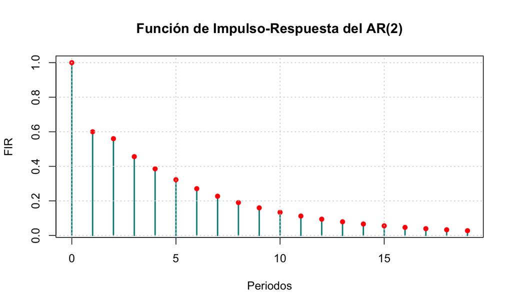

## Función de autocovarianza y autocorrelación

## Función de autocovarianza y autocorrelación

Consideremos un modelo ARMA(\(p\),\(q\)):

\[ \Phi(L) y_t = \Theta(L)\varepsilon_{t}\\ \varepsilon_t \sim WN(0,\sigma^2) \]

Deseamos calcular la funciones de autocovarianza y de autocorrelación. Para esto, conviene invertir el proceso en su forma MA(\(\infty\)).

## Función de Autocovarianza y Autocorrelación: MA(\(1\))

Para un proceso MA(\(1\)):

\[ y_t = \varepsilon_t + \theta_1 \varepsilon_{t-1} \]

es fácil demostrar que:

\[ \gamma(h) = \begin{cases} (1 + \theta_1^2) \sigma^2 & h=0\\ \theta_1 \sigma^2 & |h|=1\\ 0 & |h|>1 \end{cases} \qquad \rho(h) = \begin{cases} 1 & h=0\\ \frac{\theta_1}{1 + \theta_1^2} & |h|=1\\ 0 & |h|>1 \end{cases} \]

Nota que este proceso cumple con las condiciones de estacionariedad y ergodicidad.

## Función de Autocovarianza y Autocorrelación: MA(\(q\))

Ahora, para un proceso MA(\(q\)):

\[ y_t = \varepsilon_t + \theta_1 \varepsilon_{t-1} + \theta_2 \varepsilon_{t-2} + \dots + \theta_q \varepsilon_{t-q} \]

tenemos:

\[ \gamma(h) = \begin{cases} \sigma^2 \sum_{i=0}^{q} \theta_i^2 & h=0\\ \sigma^2 \sum_{i=0}^{q-h} \theta_i\theta_{i+h} & 1\leq |h| \leq q\\ 0 & |h|>q \end{cases} \qquad \rho(h) = \begin{cases} 1 & h=0\\ \frac{\sum_{i=0}^{q-h} \theta_i\theta_{i+h}}{\sum_{i=0}^{q} \theta_i^2} & 1\leq |h| \leq q\\ 0 & |h|>1 \end{cases} \]

donde \(\theta_0 = 1\). Este proceso es, naturalmente, estacionario y ergódico.

## Función de Autocovarianza y Autocorrelación: MA(\(\infty\)) (1/4)

¿Será un proceso MA(\(\infty\)) estacionario? Si lo fuera:

\[ \gamma(h) = \begin{cases} \sigma^2 \sum_{i=0}^{\infty} \theta_i^2 & h=0\\ \sigma^2 \sum_{i=0}^{\infty} \theta_i\theta_{i+h} & |h| \geq 1 \end{cases} \qquad \rho(h) = \begin{cases} 1 & h=0\\ \frac{\sum_{i=0}^{\infty} \theta_i\theta_{i+h}}{\sum_{i=0}^{\infty}\theta_i^2} & |h| \geq 1\\ \end{cases} \]

donde \(\theta_0 = 1\). Nota que la estacionariedad de este proceso depende del término \(\sum_{i=0}^{\infty} \theta_i^2\). ¿Es este término finito?

## Función de Autocovarianza y Autocorrelación: MA(\(\infty\)) (2/4)

Proposición

Si \({\varepsilon_t}\) es una secuencia de ruidos blancos con media cero y varianza finita, \(\sigma^2<\infty\), y si \(\sum_{i=0}^\infty \theta_i^2 < \infty\), entonces la serie:

\[ y_t = \sum_{i=0}^\infty \theta_i \varepsilon_{t-i} \]

**converge en media cuadrática**.

## Función de Autocovarianza y Autocorrelación: MA(\(\infty\)) (3/4)

En ocasiones, resulta más fácil utilizar la condición de **convergencia absoluta**. Esta requiere:

\[ \sum_{i=0}^\infty |\theta_i|<\infty \]

Se puede demostrar que, *si un proceso converge en valor absoluto, también lo hace en media cuadrática*.

## Función de Autocovarianza y Autocorrelación: MA(\(\infty\)) (4/4)

Ejemplo

Consideremos un proceso AR(\(1\)):

\[ \begin{align} y_t &= \phi_1 y_{t-1} + \varepsilon_t \\ \varepsilon_t &\sim WN(0,\sigma^2) \end{align} \]

Si \(|\phi_1|<1\), este proceso es *invertible y estacionario*, puesto que:

\[ y_t = \sum_{i=0}^{\infty} \phi_1^i \varepsilon_{t-i} \ \iff \ \sum_{i=0}^\infty |\phi_1^i| < \infty \]

## Descomposición de Wold (1/2)

Teorema (Wold)

Sea \(\{y_t\}\) un proceso débilmente estacionario con media cero y varianza finita. Entonces existe una representación única de la forma:

\[ y_t = \sum_{i=0}^{\infty} \psi_i \,\varepsilon_{t-i}, \qquad \psi_0 = 1, \qquad \sum_{i=0}^{\infty} \psi_i^2 < \infty, \]

donde \(\{\varepsilon_t\}\) es un proceso de ruido blanco con media cero y varianza finita \(\sigma^2\).

## Teorema de Wold (2/2)

Nota

En los procesos ARMA(\(p,q\)):

- *Estacionariedad*: se garantiza cuando las raíces del polinomio \(\Phi(L)=0\) están fuera del círculo unitario.
- *Invertibilidad*: se garantiza cuando las raíces del polinomio \(\Theta(L)=0\) están fuera del círculo unitario.

## Ecuaciones de Yule-Walker

## Ecuaciones de Yule-Walker (1/6)

Para calcular las funciones de autocovarianza y autocorrelación de un proceso AR(\(p\)), también podemos utilizar las **ecuaciones de Yule-Walker**:

\[ \begin{align} y_t &= \phi_1 y_{t-1} + \phi_2 y_{t-2} + \dots + \phi_p y_{t-p} + \varepsilon_t \\ \varepsilon_t &\sim WN(0,\sigma^2) \end{align} \]

- Multiplicamos ambos lados de la ecuación por \(y_t\) y calculamos el valor esperado:

\[ \gamma(0) = \phi_1 \gamma(1) + \phi_2 \gamma(2) + \dots + \phi_p \gamma(p) + \sigma^2 \]

## Ecuaciones de Yule-Walker (2/6)

Para calcular las funciones de autocovarianza y autocorrelación de un proceso AR(\(p\)), podemos utilizar las ecuaciones de Yule-Walker:

- Dividimos el resultado por \(\gamma(0)\):

\[ 1 = \phi_1 \rho(1) + \phi_2 \rho(2) + \dots + \phi_p \rho(p) + \frac{\sigma^2}{\gamma(0)} \]

- Repetimos los dos pasos previos, pero ahora multiplicando ambos lados del proceso por \(y_{t-1}\):

\[ \rho(1) = \phi_1 + \phi_2 \rho(1) + \phi_3\rho(2) + \dots + \phi_p\rho(p-1) \]

## Ecuaciones de Yule-Walker (3/6)

Para calcular las funciones de autocovarianza y autocorrelación de un proceso AR(\(p\)), podemos utilizar las ecuaciones de Yule-Walker:

- Repetimos los primeros dos pasos, pero ahora multiplicando ambos lados del proceso por \(y_{t-2}\):

\[ \rho(2) = \phi_1\rho(1) + \phi_2 + \phi_3\rho(1) + \dots + \phi_p\rho(p-2) \]

- Repetimos los primeros dos pasos, pero ahora multiplicando ambos lados del proceso por \(y_{t-3}, y_{t-4},\dots\). En general, si multiplicamos por \(y_{t-k}\):

\[ \rho(k) = \phi_1\rho(k-1) + \phi_2\rho(k-2) + \dots + \phi_{p-k} + \phi_{p-k+1}\rho(1) + \dots + \phi_p\rho(p-k) \]

## Ecuaciones de Yule-Walker (4/6)

Para calcular las funciones de autocovarianza y autocorrelación de un proceso AR(\(p\)), podemos utilizar las ecuaciones de Yule-Walker:

- Nota que, *si conocemos los valores de los coeficientes*, \(\phi_1, \phi_2, \dots, \phi_p\), podemos obtener la función de autocorrelación resolviendo el sistema de ecuaciones de forma recursiva.

## Ecuaciones de Yule-Walker (5/6)

Para calcular las funciones de autocovarianza y autocorrelación de un proceso AR(\(p\)), podemos utilizar las ecuaciones de Yule-Walker:

- Finalmente, nota que:

\[ \gamma(0) = \frac{\sigma^2}{1-\phi_1\rho(1)-\phi_2\rho(2) - \dots - \phi_p\rho(p)} \]

- La función de autocovarianza se encuentra usando este resultado y recordando que:

\[ \rho(k) = \frac{\gamma(k)}{\gamma(0)} \]

## Ecuaciones de Yule-Walker (6/6)

Ejercicio

Muestra que, para un proceso AR(\(2\)), la función de autocorrelación es:

\[ \begin{align} \rho(1) &= \frac{\phi_1}{1-\phi_2} \\ \rho(2) &= \frac{\phi_1^2}{1-\phi_2} + \phi_2 \\ \rho(3) &= \frac{\phi_1^3}{1-\phi_2} + \phi_1\phi_2 + \frac{\phi_1\phi_2}{1-\phi_2} \\ & \vdots \end{align} \]

## Estimación de los coeficientes de un AR(\(p\)) (1/2)

El procedimiento de Yule-Walker nos permite plantear la **fórmula de Yule-Walker**:

\[ \mathbf{R \Phi} = \mathbf{r} \]

Donde: \[ \mathbf{R}=\begin{pmatrix} 1 & \rho_1 & \rho_2 & \dots & \rho_{p-2} & \rho_{p-1} \\ \rho_1 & 1 & \rho_1 & \dots & \rho_{p-3} & \rho_{p-2} \\ \vdots & \vdots & \vdots & \dots & \vdots & \vdots \\ \rho_{p-2} & \rho_{p-3} & \rho_{p-4} & \dots & 1 & \rho_{1} \\ \rho_{p-1} & \rho_{p-2} & \rho_{p-3} & \dots & \rho_{1} & 1 \\ \end{pmatrix}; \quad \mathbf{\Phi} = \begin{pmatrix}\phi_1 \\ \phi_2 \\ \vdots \\ \phi_{p-1} \\ \phi_p \end{pmatrix}; \quad \mathbf{r}=\begin{pmatrix}\rho_1 \\ \rho_2 \\ \vdots \\ \rho_{p-1} \\ \rho_p \end{pmatrix} \]

## Estimación de los coeficientes de un AR(\(p\)) (2/2)

Nota

1. *Si conocemos (o estimamos) la función de autocorrelación*, \(\rho_1, \rho_2, \dots, \rho_p\), podemos encontrar estimadores para los coeficientes de un proceso AR(\(p\)):

   \[ \mathbf{\hat{\Phi}}^{YW} = \mathbf{R}^{-1} \mathbf{r} \]
2. Dado que la matriz \(\mathbf{R}\) es cuadrada, simétrica y de rango completo, la matriz \(\mathbf{R}^{-1}\) existe. Además, cada elemento del vector \(\mathbf{\hat{\Phi}}^{YW}\) puede encontrarse mediante la **regla de Cramer**.

## La función de autocorrelación parcial (1/5)

Nota que un proceso AR(\(p\)) puede escribirse como:

\[ \begin{align} y_t &= \phi_1 y_{t-1} + \phi_2 y_{t-2} + \dots + \phi_p y_{t-p} + 0\cdot y_{t-p-1} + 0\cdot y_{t-p-2} + \dots + 0\cdot y_{t-p-m} + \varepsilon_t \\ \varepsilon_t &\sim WN(0,\sigma^2) \end{align} \] Esto es, *si realmente tenemos un proceso AR(\(p\))* todos los coeficientes:

\[ \begin{align} \phi_{p+1} &= \phi_{p+2} = \dots = \phi_{p+m} \\ &= 0 \end{align} \]

## La función de autocorrelación parcial (2/5)

Lo anterior indica que, si tenemos un proceso AR(\(p\)), pero usamos la fórmula de Yule-Walker para estimar los coeficientes de un AR(\(p+m\)), deberíamos encontrar:

- Los coeficientes estimados \(\phi_1^{YW}, \phi_2^{YW}, \dots, \phi_p^{YW}\) son estadísticamente diferentes de cero.
- Los coeficientes estimados \(\phi_{p+1}^{YW}, \phi_{p+2}^{YW}, \dots, \phi_{p+m}^{YW}\) son estadísticamente iguales a cero.

## La función de autocorrelación parcial (3/5)

La **función de autocorrelación parcial (FACP)**, no es más que la secuencia de coeficientes \(\phi_{kk}\) del sistema:

\[ \begin{align} y_t &= \phi_{11}y_{t-1} + \varepsilon_{1t}\\ y_t &= \phi_{21}y_{t-1} + \phi_{22}y_{t-2} + \varepsilon_{2t}\\ y_t &= \phi_{31}y_{t-1} + \phi_{32}y_{t-2} + \phi_{33}y_{t-3} + \varepsilon_{3t}\\ &\vdots\\ y_t &= \phi_{k1}y_{t-1} + \phi_{k2}y_{t-2} + \dots + \phi_{kk}y_{t-k} + \varepsilon_{kt}\\ \end{align} \]

## La función de autocorrelación parcial (4/5)

La FACP puede encontrarse mediante la aplicación sucesiva de la fórmula de Yule-Walker:

1. Se establece un punto de corte, por ejemplo, sea \(p=T/4\).
2. Sea \(1\leq k \leq p\) y sean \(\mathbf{R}^{(i)}\) y \(\mathbf{r}^{(i)}\) las versiones de las matrices \(\mathbf{R}\) y \(\mathbf{r}\) de la fórmula de Yule-Walker para el caso \(k\)-ésimo. Para cada valor de \(k\): \[ \mathbf{\hat{\Phi}}^{(k)} = (\mathbf{R}^{(k)})^{-1} \mathbf{r}^{(k)} = \begin{pmatrix}\hat{\phi_1} \\ \hat{\phi_2} \\ \vdots \\ \hat{\phi_k} \end{pmatrix} \]
3. Naturalmente, \(\phi_{kk} = \hat{\phi}_k\).

## La función de autocorrelación parcial (5/5)

Ejercicio

Muestra que, para un proceso AR(\(2\)), la función de autocorrelación parcial es:

\[ \begin{align} \phi_{11} &= \rho_1 \\ \phi_{22} &= \frac{\rho_2-\rho_1^2}{1-\rho_1^2} \end{align} \]

## Estimación por Máxima verosimilitud

## Función de verosimilitud: Preliminares

Pensemos en una serie de tiempo como una secuencia de variables aleatorias \(\{Y_t\}_{t=1}^T\), con realizaciones \(\{y_t\}_{t=1}^T\). Si esta serie de tiempo sigue un proceso ARMA(\(p\),\(q\)) y *todos sus parámetros son conocidos*, podemos plantear su **función de densidad conjunta**.

Para esto, hacemos uso de lo siguiente:

1. Sean \(X\), \(Y\) y \(Z\) tres variables aleatorias con realizaciones \(x\), \(y\) y \(z\), respectivamente. Entonces:

   \[ f_{X,Y}(x,y) = f_{X}(x)f_{Y|X}(y|x) \]
2. Además, la densidad conjunta condicional se descompone como:

   \[ f_{X,Y|Z}(x,y|z) = f_{X|Z}(x|z)f_{Y|X,Z}(y|x,z) \]

## Función de densidad conjunta (1/5)

Para empezar, sea, \(X=Y_1\) y \(Y=Y_2, Y_3,\dots, Y_T\). Entonces:

\[ \begin{align} f_{X,Y}(x,y) &= f_{X}(x)f_{Y|X}(y|x) \\ &= f_{Y_1}(y_1)f_{Y_2,Y_3,\dots,Y_T|Y_1}(y_2,y_3,\dots,y_T|y_1) \end{align} \]

## Función de densidad conjunta (2/5)

Pero, nota que si ahora \(X=Y_2\), \(Y=Y_3, Y_4,\dots, Y_T\) y \(Z=Y_1\), tenemos:

\[ \begin{align} f_{X,Y|Z}(x,y|z) &= f_{X|Z}(x|z)f_{Y|X,Z}(y|x,z) \\ &= f_{Y_2|Y_1}(y_2|y_1)f_{Y_3,Y_4,\dots,Y_T|Y_1, Y_2}(y_3,y_4,\dots,y_T|y_1, y_2) \end{align} \]

Por lo tanto:

\[ \begin{align} f_{X,Y}(x,y) &= f_{X}(x)f_{Y|X}(y|x) \\ &= f_{Y_1}(y_1)f_{Y_2|Y_1}(y_2|y_1)f_{Y_3,Y_4,\dots,Y_T|Y_1, Y_2}(y_3,y_4,\dots,y_T|y_1, y_2) \end{align} \]

## Función de densidad conjunta (3/5)

Podemos encontrar \(f_{Y_3,Y_4,\dots,Y_T|Y_1, Y_2}(y_3,y_4,\dots,y_T|y_1, y_2)\) si definimos ahora \(X=Y_3\), \(Y=Y_4, Y_5,\dots,Y_T\) y \(Z=Y_1,Y_2\):

\[ \begin{align} f_{X,Y|Z}(x,y|z) &= f_{X|Z}(x|z)f_{Y|X,Z}(y|x,z) \\ &= f_{Y_3|Y_1, Y_2}(y_3|y_1, y_2)f_{Y_4,Y_5,\dots,Y_T|Y_1, Y_2, Y_3}(y_4,y_5,\dots,y_T|y_1, y_2, y_3) \end{align} \]

Por lo tanto:

\[ \begin{align} f_{X,Y}(x,y) &= f_{X}(x)f_{Y|X}(y|x) \\ &= f_{Y_1}(y_1)f_{Y_2|Y_1}(y_2|y_1)f_{Y_3|Y_1, Y_2}(y_3|y_1,y_2)f_{Y_4,Y_5,\dots,Y_T|Y_1, Y_2, Y_3}(y_4,y_5,\dots,y_T|y_1, y_2, y_3) \end{align} \]

## Función de densidad conjunta (4/5)

Si continuamos con el mismo razonamiento, es fácil encontrar que la función de densidad conjunta las variables aleatorias \(\{Y_t\}_{t=1}^T\) es:

\[ \begin{align} f_{Y_1, Y_2, \dots, Y_T}(y_1, y_2,\dots,y_T) &= f_{Y_1}(y_1) \times f_{Y_2|Y_1}(y_2|y_1) \times f_{Y_3|Y_2,Y_1}(y_3|y_2,y_1) \times \dots \\ &\times f_{Y_T|Y_{T-1},Y_{T-2},\dots,Y_{1}}(y_T|y_{T-1},y_{T-2},\dots,y_{1}) \\ & = f_{Y_1}(y_1) \times \prod_{t=2}^T f_{Y_t|Y_{t-1},Y_{t-2},\dots,Y_{1}}(y_t|y_{t-1},y_{t-2},\dots,y_{1}) \end{align} \]

## Función de densidad conjunta (5/5)

Lo anterior puede aplicarse para cualquier distribución que se le asigne a las variables \(Y_t\). Sin embargo, conviene recordar que si \(Y_t \sim \mathcal{N}(\mu_Y, \sigma^2_Y)\):

\[ f_{Y_t}(y_t)= \frac{1}{\sqrt{2\pi\sigma_Y^2 }}\exp\left\{ -\frac{1}{2\sigma_Y^2}(Y_t-\mu_Y)^2\right\} \]

Y si \(\mathbf{Y} \sim \mathcal{N}(\mathbf{\mu}_Y, \mathbf{\Sigma}_Y)\)

\[ f_{\mathbf{Y}}(\mathbf{y})= (2\pi)^{-\frac{k}{2}}|\mathbf{\Sigma}|^{-\frac{1}{2}}\exp\left\{ -\frac{1}{2}(\mathbf{Y}-\mathbf{\mu}_Y)'\mathbf{\Sigma}^{-1}(\mathbf{Y}-\mathbf{\mu}_Y)\right\} \]

## Función de densidad conjunta: ejemplo (1/6)

Supongamos que la serie de tiempo, \(y_t\) sigue un proceso AR(\(1\)):

\[ \begin{align} y_t &= \phi_0 + \phi_1 y_{t-1} + \varepsilon_t \\ \varepsilon_t &\sim iid\mathcal{N}(0,\sigma^2) \end{align} \]

donde, de momento, *todos los parámetros del modelo son conocidos*. De antes, sabemos que:

\[ \begin{align} \mu_y &= \frac{\phi_0}{1-\phi_1} \\ &=\mu\\ \sigma^2_y &= \frac{\sigma^2}{1-\phi_1^2}\\ &=\gamma_0 \end{align} \]

## Función de densidad conjunta: ejemplo (2/6)

Primero, necesitamos calcular \(f_{Y_1}(y_1)\). Dado que hemos supuesto que \(\varepsilon_t\) sigue una distrubución \(iid\mathcal{N}\), podemos concluir que:

\[ y_t \sim \mathcal{N}(\mu, \gamma_0) \]

Entonces:

\[ \begin{align} f_{Y_1}(y_1)&= \frac{1}{\sqrt{2\pi\gamma_0 }}\exp\left\{ -\frac{1}{2\gamma_0}(y_1-\mu)^2\right\}\\ &= \frac{1}{\sqrt{2\pi\gamma_0 }}\exp\left\{ -\frac{1}{2\gamma_0}\varepsilon_1^2\right\} \end{align} \]

## Función de densidad conjunta: ejemplo (3/6)

Ahora necesitamos \(\mathbb{E}(y_2|y_1)\). Nota que:

\[ \begin{align} \mathbb{E}(y_2|y_1) &=\phi_0 + \phi_1 y_1\\ \mathbb{V}ar(y_2|y_1) &= \sigma^2 \end{align} \]

Por lo tanto:

\[ \begin{align} f_{Y_2|Y_1}(y_2|y_1) &= \frac{1}{\sqrt{2\pi\sigma^2 }}\exp\left\{ -\frac{1}{2\sigma^2}(y_2-\phi_0 - \phi_1y_1)^2\right\} \\ &= \frac{1}{\sqrt{2\pi\sigma^2 }}\exp\left\{ -\frac{1}{2\sigma^2}\varepsilon_2^2\right\} \end{align} \]

## Función de densidad conjunta: ejemplo (4/6)

Ahora necesitamos \(\mathbb{E}(y_3|y_1, y_2)\). Nota que:

\[ \begin{align} \mathbb{E}(y_3|y_1,y_2) &=\phi_0 + \phi_1 y_2\\ \mathbb{V}ar(y_3|y_1, y_2) &= \sigma^2 \end{align} \]

Por lo tanto:

\[ \begin{align} f_{Y_3|Y_1, Y_2}(y_3|y_1, y_2) &= \frac{1}{\sqrt{2\pi\sigma^2 }}\exp\left\{ -\frac{1}{2\sigma^2}(y_3-\phi_0 - \phi_1y_2)^2\right\}\\ &= \frac{1}{\sqrt{2\pi\sigma^2 }}\exp\left\{ -\frac{1}{2\sigma^2}\varepsilon_3^2\right\} \end{align} \]

## Función de densidad conjunta: ejemplo (5/6)

Dado que tenemos un proceso AR(\(1\)), es fácil demostrar que para \(k\geq2\):

\[ \begin{align} \mathbb{E}(y_k|y_1,y_2,\dots,y_{k-1}) &=\phi_0 + \phi_1 y_{k-1}\\ \mathbb{V}ar(y_k|y_1,y_2,\dots,y_{k-1}) &= \sigma^2 \end{align} \]

Por lo tanto:

\[ \begin{align} f_{Y_k|Y_1, Y_2,\dots Y_{k-1}}(y_k|y_1,y_2,\dots,y_{k-1}) &= \frac{1}{\sqrt{2\pi\sigma^2 }}\exp\left\{ -\frac{1}{2\sigma^2}(y_k-\phi_0 - \phi_1y_{k-1})^2\right\}\\ &= \frac{1}{\sqrt{2\pi\sigma^2 }}\exp\left\{ -\frac{1}{2\sigma^2}\varepsilon_k^2\right\}\\ \end{align} \]

## Función de densidad conjunta: ejemplo (6/6)

Entonces, la función de densidad conjunta de un proceso AR(\(1\)) es:

\[ f_{Y_1, Y_2,\dots,Y_T}(y_1, y_2,\dots,y_T) = \frac{1}{\sqrt{2\pi\gamma_0 }}\exp\left\{ -\frac{1}{2\gamma_0}\varepsilon_1^2\right\} \times \prod_{k=2}^{T}\frac{1}{\sqrt{2\pi\sigma^2 }}\exp\left\{ -\frac{1}{2\sigma^2}\varepsilon_k^2\right\} \]

## Función de verosimilitud

La **función de verosimilitud** no es más que la función de densidad conjunta cuando *los parámetros del modelo son desconocidos*.

En el caso de un proceso AR(\(1\)), por ejemplo, los coeficientes \(\phi_0\), \(\phi_1\), así como \(\sigma^2\), son desconocidos, por lo que su función de verosimilitud es:

\[ \begin{align} L(\phi_0, \phi_1, \sigma^2) &= \frac{1}{\sqrt{2\pi\gamma_0 }}\exp\left\{ -\frac{1}{2\gamma_0}\left(y_1-\frac{\phi_0}{1-\phi_1}\right)^2\right\}\\ &\times \prod_{k=2}^{T}\frac{1}{\sqrt{2\pi\sigma^2 }}\exp\left\{ -\frac{1}{2\sigma^2}(y_k-\phi_0-\phi_1y_{k-1})^2\right\} \end{align} \]

## Función de log-verosimilitud

En ocasiones, resulta más conveniente calcular la **función de log-verosimilitud**. Esta no es más que el *logaritmo natural de la función de verosimilitud*.

En el caso de un proceso AR(\(1\)), por ejemplo, tenemos que la función de log-verosimilud es:

\[ \begin{align} \mathcal{L}(\phi_0, \phi_1, \sigma^2) = &-\frac{T}{2}\ln(2\pi)-\frac{1}{2}\ln\left(\frac{\sigma^2}{1-\phi_1^2}\right)\\ &-\frac{\left[y_1 - \phi_0/(1-\phi_1)\right]^2}{2\sigma^2/(1-\phi_1)} - \left(\frac{T-1}{2}\right)\ln(\sigma^2)\\ &- \sum_{k=2}^{T}\left\{ -\frac{1}{2\sigma^2}(y_k-\phi_0-\phi_1y_{k-1})^2\right\} \end{align} \]

## Función de verosimilitud de un AR(\(p\)) (1/6)

Consideremos ahora un proceso AR(\(p\)):

\[ \begin{align} y_t &= \phi_0 + \phi_1 y_{t-1} + \phi_2 y_{t-2} + \dots + \phi_p y_{t-p} + \varepsilon_t \\ \varepsilon_t&\sim iid\mathcal{N}(0,\sigma^2) \end{align} \]

Para calcular la función de verosimilitud, necesitamos primero calcular la función de densidad conjunta *de las primeras \(p\) observaciones*, las cuales agruparemos en el vector \(\mathbf{y}_p\):

\[ \mathbf{y}_p = \begin{pmatrix} y_1 \\ y_2 \\ \vdots\\ y_{p} \end{pmatrix} \]

## Función de verosimilitud de un AR(\(p\)) (2/6)

De antes, podemos deducir que:

\[ \mathbf{y}_p \sim \mathcal{N}(\boldsymbol{\mu},\mathbf{\Sigma}) \] donde:

\[ \boldsymbol{\mu} = \begin{pmatrix} \mu \\ \mu \\ \vdots\\ \mu \end{pmatrix}; \qquad \mathbf{\Sigma} = \begin{pmatrix} \gamma_0 & \gamma_1 & \gamma_2 & \gamma_3 & \dots & \gamma_{p-1}\\ \gamma_1 & \gamma_0 & \gamma_1 & \gamma_2 & \dots & \gamma_{p-2}\\ \gamma_2 & \gamma_1 & \gamma_0 & \gamma_1 & \dots & \gamma_{p-3}\\ \vdots & \vdots& \vdots & \vdots & \ddots & \vdots\\ \gamma_{p-1} & \gamma_{p-2} & \gamma_{p-3} & \gamma_{p-4} & \dots & \gamma_{0}\\ \end{pmatrix} \]

Y, naturalmente:

\[ \mu = \frac{\phi_0}{1-\phi_1-\phi_2-\dots-\phi_p}; \qquad \gamma_h = \gamma(h) \]

## Función de verosimilitud de un AR(\(p\)) (3/6)

Entonces, para el vector \(\mathbf{y}_p\):

\[ f_{Y_1, Y_2,\dots,Yp}(y_1, y_2, \dots, y_p)= (2\pi)^{\frac{p}{2}}|\mathbf{\Sigma}|^{-\frac{1}{2}}\exp\left\{ -\frac{1}{2}(\mathbf{y}_p-\mu)'\mathbf{\Sigma}^{-1}(\mathbf{y}_p-\mu)\right\} \]

Además, siguiendo un procedimiento similar al de un AR(\(1\)), es fácil encontrar que para el resto de las observaciones (\(k>p\)):

\[ \begin{align} f_{Y_k|Y_1, Y_2,\dots Y_{k-1}}(y_k|y_1,y_2,\dots,y_{k-1}) &= \frac{1}{\sqrt{2\pi\sigma^2 }}\exp\left\{ -\frac{1}{2\sigma^2}(y_k-\phi_0 - \phi_1y_{k-1}-\phi_2y_{k-2}-\dots-\phi_p y_{k-p})^2\right\}\\ &= \frac{1}{\sqrt{2\pi\sigma^2 }}\exp\left\{ -\frac{1}{2\sigma^2}\varepsilon_k^2\right\}\\ \end{align} \]

## Función de verosimilitud de un AR(\(p\)) (4/6)

Entonces, la función de verosimilitud para un proceso ARMA(\(p\)) es:

\[ \begin{align} L(\phi_0,\phi_1,\dots,\phi_p,\sigma^2) &= (2\pi)^{-\frac{p}{2}}|\mathbf{\Sigma}|^{-\frac{1}{2}}\exp\left\{ -\frac{1}{2}(\mathbf{y}_p-\mu)'\mathbf{\Sigma}^{-1}(\mathbf{y}_p-\mu)\right\} \\ &\times \prod_{k=p+1}^T\frac{1}{\sqrt{2\pi\sigma^2 }}\exp\left\{ -\frac{1}{2\sigma^2}\varepsilon_k^2\right\} \end{align} \]

Y la función de log-verosimilitud:

\[ \begin{align} \mathcal{L}(\phi_0,\phi_1,\dots,\phi_p,\sigma^2) = &-\frac{T}{2}\ln(2\pi)+\frac{1}{2}\ln|\mathbf{\Sigma}|^{-\frac{1}{2}} - \frac{1}{2}(\mathbf{y}_p-\mu)'\mathbf{\Sigma}^{-1}(\mathbf{y}_p-\mu) \\ &- \frac{1}{2\sigma^2}\sum_{k=p+1}^T(y_t-\phi_0-\phi_1y_{t-1}-\phi_2y_{t-2}-\dots-\phi_py_{t-p})^2 \end{align} \]

## Función de verosimilitud de un AR(\(p\)) (5/6)

Nota

Para encontrar la función de verosimilitud de un AR(\(p\)) es necesario encontrar la forma de la matriz \(\mathbf{\Sigma}^{-1} = \sigma^2 \mathbf{V}^{-1}\). Sean \(v_{ij}\) los elementos de\(\mathbf{V}^{-1}\). Galbraith y Galbraith (1974) demostraron que:

\[ v_{ij} = \left[ \sum_{k=0}^{i-1}\phi_k\phi_{k+j-i} - \sum_{k=p+1-j}^{p+i-j}\phi_k\phi_{k+j-i}\right] \]

para \(1\leq i \leq j \leq p\) y \(\phi_0=-1\). Todos los elementos \(i>j\) se encuentran por simetría.

## Función de verosimilitud de un AR(\(p\)) (6/6)

Ejercicio

Muestra que para un proceso AR(\(2\)), la función de log verosimilitud es:

\[ \begin{align} \mathcal{L}(\phi_0,\phi_1,\phi_2,\sigma^2) = &-\frac{T}{2}\ln(2\pi)-\frac{T}{2}\ln(\sigma^2)+\frac{1}{2}\ln\left\{(1+\phi_2)^2[(1-\phi_2)^2-\phi_1^2]\right\} \\ &- \left(\frac{1+\phi_2}{2\sigma^2}\right) \left[(1-\phi_2)(y_1-\mu)^2-2\phi_1(y_1-\mu)(y_2-\mu)+(1-\phi_2)(y_2-\mu)^2\right] \\ &- \frac{1}{2\sigma^2}\sum_{k=3}^T(y_t-\phi_0-\phi_1y_{t-1}-\phi_2y_{t-2})^2 \end{align} \]

donde:

\[ \mu = \frac{\phi_0}{1-\phi_1-\phi_2} \]

## Estimación por máxima verosimilitud

Para estimar los coeficientes de un proceso AR(\(p\)), tenemos que *maximizar* la función de verosimilitud (o, de forma equivalente, la de log-verosimilitud) con respecto a los coeficientes desconocidos. Esta técnica se conoce como **estimación por máxima verosimilitud**.

Sin embargo, nota que esta es una función no lineal de los parámetros, por lo que *no existe solución cerrada*.

## Máxima verosimilitud condicional (1/2)

Nota que, si suponemos que las *primeras \(p\) observaciones* de la serie de tiempo, \(y_1, y_2, \dots y_p\), son deterministas, la función de verosimilitud de un proceso AR(\(p\)) se simplifica a:

\[ \begin{align} L(\phi_0,\phi_1,\dots,\phi_p,\sigma^2) &= \prod_{k=p+1}^T\frac{1}{\sqrt{2\pi\sigma^2 }}\exp\left\{ -\frac{1}{2\sigma^2}\varepsilon_k^2\right\} \end{align} \]

Y, la función de log-verosimilitud:

\[ \begin{align} \mathcal{L}(\phi_0, \phi_1, \sigma^2|y_1) = &-\frac{T-p}{2}\ln(2\pi)- \frac{T-p}{2}\ln(\sigma^2) \\ &-\frac{1}{2\sigma^2} \sum_{k=p+1}^{T}(y_k-\phi_0-\phi_1y_{k-1}-\dots-\phi_p y_{k-p})^2 \end{align} \]

Estas se conocen como funciones de **verosimilitud condicional** y de **log-verosimilitud condicional**, respectivamente. Nota que, a diferencia de la función de verosimilitud exacta, la función de verosimilitud condicional *permite una solución cerrada para los coeficientes estimados*.

## Estimación por máxima verosimilitud condicional (2/2)

Ejercicio

Muestra que si las primeras \(p\) observaciones de un AR(\(p\)) son deterministas, los coeficientes estimados por máxima verosimilitud (condicional) son equivalentes a los estimadores de MCO.

Muestra, además, que el estimador de la varianza del error es:

\[ \sigma^2 = \frac{1}{T-p}\sum_{k=p+1}^T \varepsilon_t^2 \]

## Verosimilitud condicional: Modelos ARMA(\(p\),\(q\))

## Función de verosimilitud condicional: MA(\(1\)) (1/10)

Para comenzar, consideremos un proceso MA(\(1\)):

\[ \begin{align} y_t &= \mu + \varepsilon_t + \theta \varepsilon_{t-1}\\ \varepsilon_t &\sim iid\mathcal{N}(0,\sigma^2) \end{align} \]

Primero, nota que, si conocemos \(\varepsilon_{t-1}\), siempre es posible calcular:

\[ \begin{align} \mathbb{E}(y_t|\varepsilon_{t-1}) &= \mu + \theta \varepsilon_{t-1}\\ \mathbb{V}ar(y_t|\varepsilon_{t-1}) &= \sigma^2 \end{align} \]

## Función de verosimilitud condicional: MA(\(1\)) (2/10)

Lo anterior implica que:

\[ \begin{align} y_t |\varepsilon_{t-1} \sim \mathcal{N}(\mu + \theta \varepsilon_{t-1},\sigma^2) \end{align} \]

Y, por lo tanto, para todo \(t\):

\[ \begin{align} f_{Y_t|\varepsilon_{t-1}}(y_t|\varepsilon_{t-1})&= \frac{1}{\sqrt{2\pi\sigma^2 }}\exp\left\{ -\frac{1}{2\sigma^2}(y_t-\mu-\theta \varepsilon_{t-1})^2\right\} \end{align} \]

## Función de verosimilitud condicional: MA(\(1\)) (3/10)

Nota que, cuando \(t=1\):

\[ y_1 = \mu + \varepsilon_1 + \theta_1 \varepsilon_0 \]

Dado que no conocemos \(\varepsilon_0\), podemos hacer el supuesto adicional que \(\varepsilon_0=0\). Entonces, en este caso:

\[ \begin{align} f_{Y_1|\varepsilon_{0}}(y_1|\varepsilon_{0}=0)&= \frac{1}{\sqrt{2\pi\sigma^2 }}\exp\left\{ -\frac{1}{2\sigma^2}(y_1-\mu)^2\right\}\\ &= \frac{1}{\sqrt{2\pi\sigma^2 }}\exp\left\{ -\frac{1}{2\sigma^2}\varepsilon_1^2\right\} \end{align} \]

## Función de verosimilitud condicional: MA(\(1\)) (4/10)

Ahora, para \(t=2\):

\[ y_2 = \mu + \varepsilon_2 + \theta_1 \varepsilon_1 \]

*Si condicionamos a que \(Y_1=y_1\), entonces \(\varepsilon_1\) se vuelve conocido*. Entonces:

\[ \begin{align} f_{Y_2|Y_1,\varepsilon_{0}}(y_2|y_1,\varepsilon_{0}=0)&= \frac{1}{\sqrt{2\pi\sigma^2 }}\exp\left\{ -\frac{1}{2\sigma^2}(y_2-\mu-\theta_1\varepsilon_{1})^2\right\}\\ &= \frac{1}{\sqrt{2\pi\sigma^2 }}\exp\left\{ -\frac{1}{2\sigma^2}\varepsilon_2^2\right\} \end{align} \]

## Función de verosimilitud condicional: MA(\(1\)) (5/10)

Ahora, para \(t=3\):

\[ y_3 = \mu + \varepsilon_3 + \theta_1 \varepsilon_2 \]

Y, si condicionamos a que \(Y_1=y_1\) \(Y_2=y_2\), entonces:

\[ \begin{align} f_{Y_3|Y_1,Y_2,\varepsilon_{0}}(y_3|y_1,y_2,\varepsilon_{0}=0)&= \frac{1}{\sqrt{2\pi\sigma^2 }}\exp\left\{ -\frac{1}{2\sigma^2}(y_3-\mu-\theta_1\varepsilon_{2})^2\right\}\\ &= \frac{1}{\sqrt{2\pi\sigma^2 }}\exp\left\{ -\frac{1}{2\sigma^2}\varepsilon_3^2\right\} \end{align} \]

## Función de verosimilitud condicional: MA(\(1\)) (6/10)

Queda claro que, para todo \(t\):

\[ y_t = \mu + \varepsilon_{t} + \theta_1 \varepsilon_{t-1} \]

Y:

\[ \begin{align} f_{Y_t|Y_{1},Y_{2},\dots,Y_{t-1},\varepsilon_{0}}(y_t|y_{1},y_{2},\dots,y_{t-1},\varepsilon_{0}=0)&= \frac{1}{\sqrt{2\pi\sigma^2 }}\exp\left\{ -\frac{1}{2\sigma^2}(y_t-\mu-\theta_1\varepsilon_{t-1})^2\right\}\\ &= \frac{1}{\sqrt{2\pi\sigma^2 }}\exp\left\{ -\frac{1}{2\sigma^2}\varepsilon_t^2\right\} \end{align} \]

## Función de verosimilitud condicional: MA(\(1\)) (7/10)

Entonces, la función de densidad conjunta condicionada a que \(\varepsilon_0=0\) para las \(T\) observaciones es:

\[ f_{Y_1, Y_2,\dots,Y_T|\varepsilon_0 =0}(y_1, y_2,\dots,y_T|\varepsilon_0 =0) = f_{Y_1|\varepsilon_0}((y_1|\varepsilon_0 =0) \times \prod_{k=2}^{T}f_{Y_t|Y_{1},Y_{2},\dots,Y_{t-1},\varepsilon_{0}}(y_t|y_{1},y_{2},\dots,y_{t-1},\varepsilon_{0}=0) \]

## Función de verosimilitud condicional: MA(\(1\)) (8/10)

Cuando no conocemos los parámetros del proceso, tenemos la función de verosimilitud:

\[ L(\mu, \theta_1,\sigma^2|\varepsilon_0=0) = \prod_{k=1}^{T}\frac{1}{\sqrt{2\pi\sigma^2 }}\exp\left\{ -\frac{1}{2\sigma^2}\varepsilon_t^2\right\} \]

Y la función de log-verosimilitud:

\[ \mathcal{L}(\mu, \theta_1,\sigma^2|\varepsilon_0=0) = -\frac{T}{2}\ln(2\pi)-\frac{T}{2}\ln \sigma^2-\frac{1}{2\sigma^2}\sum_{k=1}^{T}\varepsilon_t^2 \]

Con:

\[ \varepsilon_t = \begin{cases} y_1 - \mu; & t=1\\ y_t - \mu - \theta_1 \varepsilon_{t-1}; & t>1 \end{cases} \]

## Función de verosimilitud condicional: MA(\(1\)) (9/10)

Nota

Para realizar el cálculo anterior, hemos supuesto que \(\varepsilon_0=0\). ¿Qué tan importante es este supuesto?

Nota que, en cada periodo \(t\):

\[ \varepsilon_t = y_t - \mu - \theta_1\varepsilon_{t-1} \]

Esta no es más que una *ecuación en diferencias* para \(\varepsilon_t\) con condición inicial \(\varepsilon_0=0\).

## Función de verosimilitud condicional: MA(\(1\)) (10/10)

Nota

Si resolvemos la ecuación en diferencias para \(\varepsilon_t\):

\[ \varepsilon_t = \sum_{i=0}^{t-1} (-1)^i\theta_1^i(y_{t-i}-\mu) + (-1)^t\theta_1^t\varepsilon_0 \]

Entonces, si \(|\theta_1|<1\), el coeficiente \(\theta_1^t\) converge a cero conforme \(t\) crece. Por lo tanto, el supuesto de \(\varepsilon_0=0\) deja de tener importancia en tanto la serie de tiempo sea lo suficientemente larga.

## Función de verosimilitud condicional: MA(\(q\)) (1/3)

Podemos seguir el procedimiento anterior para encontrar la función de verosimilitud para un MA(\(q\)):

\[ \begin{align} y_t &= \mu + \varepsilon_t + \theta_1 \epsilon_{t-1} + \theta_2 \varepsilon_{t-2}+\dots+ \theta_q \varepsilon_{t-q}\\ \varepsilon_t &\sim iid\mathcal{N}(0,\sigma^2) \end{align} \]

Igual que antes, debemos establecer algunos supuestos sobre el comportamiento de \(\varepsilon_t\) para poder plantear la función de verosimilitud condicional.

## Función de Verosimilitud condicional: MA(\(q\)) (2/3)

Ahora, es necesario suponer que:

\[ \varepsilon_0 = \varepsilon_1 = \dots = \varepsilon_{q-1} = 0 \]

O bien que:

\[ \varepsilon_0 = \varepsilon_{-1} = \dots = \varepsilon_{-q+1} = 0 \] *¿Por qué?*

## Función de Verosimilitud condicional: MA(\(q\)) (3/3)

Bajo alguno de los supuestos anteriores, podemos calcular:

\[ \varepsilon_t = y_t - \mu - \theta_1\varepsilon_{t-1}- \theta_2\varepsilon_{t-2}-\dots-\theta_q\varepsilon_{t-q} \]

Lo cual nos permite deducir que:

\[ \mathcal{L}(\mu, \boldsymbol{\theta},\sigma^2|\boldsymbol{\varepsilon_0}=0) = -\frac{T}{2}\ln(2\pi)-\frac{T}{2}\ln \sigma^2-\frac{1}{2\sigma^2}\sum_{k=1}^{T}\varepsilon_t^2 \]

donde \(\boldsymbol{\theta} = (\theta_1 \ \theta_2 \ \dots \ \theta_q)^T\) y \(\boldsymbol{\varepsilon_0} = (\varepsilon_0 \ \varepsilon_{-1} \ \dots \ \varepsilon_{-q+1})^T\).

## Función de Verosimilitud condicional: ARMA(\(p\),\(q\)) (1/3)

Finalmente, para encontrar la función de verosimilitud condicional para un proceso ARMA(\(p\),\(q\)) establecemos (por ejemplo):

\[ y_t = \frac{\mu}{1-\phi_1-\phi_-\dots-\phi_p}; \quad t=0,-1,\dots,-p+1 \]

Y:

\[ \varepsilon_t = 0; \quad t=0,-1,\dots,-q+1 = 0 \]

## Función de Verosimilitud condicional: ARMA(\(p\),\(q\)) (2/3)

En este caso:

\[ \mathcal{L}(\mu, \boldsymbol{\phi}, \boldsymbol{\theta},\sigma^2|\mathbf{y_0},\boldsymbol{\varepsilon_0}) = -\frac{T}{2}\ln(2\pi)-\frac{T}{2}\ln \sigma^2-\frac{1}{2\sigma^2}\sum_{k=1}^{T}\varepsilon_t^2 \]

Donde \(\mathbf{y_0}\) se refiere a las condiciones iniciales establecidas para \(y_t\) y \(\boldsymbol{\varepsilon_0}\) se refiere a las condiciones iniciales establecidas para \(\varepsilon_t\).

## Función de Verosimilitud condicional: ARMA(\(p\),\(q\)) (3/3)

Nota

Para poder calcular la función de verosimilitud, otra posibilidad consiste en establecer:

\[ \varepsilon_t = 0; \quad t=0,-1,\dots,-q+1 = 0, \]

pero fijar \(y_t\), \(t=1,2,\dots,p\) en sus valores observados. Esta opción, sin embargo, implica perder las primeras \(p\) observaciones de la muestra. En este caso:

\[ \mathcal{L}(\mu, \boldsymbol{\phi}, \boldsymbol{\theta},\sigma^2|\mathbf{y_0},\boldsymbol{\varepsilon_0}) = -\frac{T-p}{2}\ln(2\pi)-\frac{T-p}{2}\ln \sigma^2-\frac{1}{2\sigma^2}\sum_{k=p+1}^{T}\varepsilon_t^2 \]

## Identificación del orden de un ARMA(\(p\),\(q\))

## Identificación del orden de un ARMA(\(p\),\(q\)) (1/8)

En ausencia de parámetros, y bajo los supuestos de *estacionariedad* y *ergodicidad*, usamos las observaciones \(\{y_t\}_{t=1}^T\) para encontrar:

- Promedio muestral
- Autocovarianza muestral
- Autocorrelación muestral
- Autocorrelación parcial

Para identificar el orden de un ARMA(\(p\),\(q\)), *comparamos el comportamiento de las medidas de dependencia serial muestrales con el comportamiento teórico* para diferentes valores de \(p\) y de \(q\).

## Identificación del orden de un ARMA(\(p\),\(q\)) (2/8)

Regla 1

La *función de autocorrelación* puede ayudarnos a saber si el modelo adecuado es un AR/ARMA o un MA. Si el modelo es un MA, la función de autocorrelación nos indica su orden.

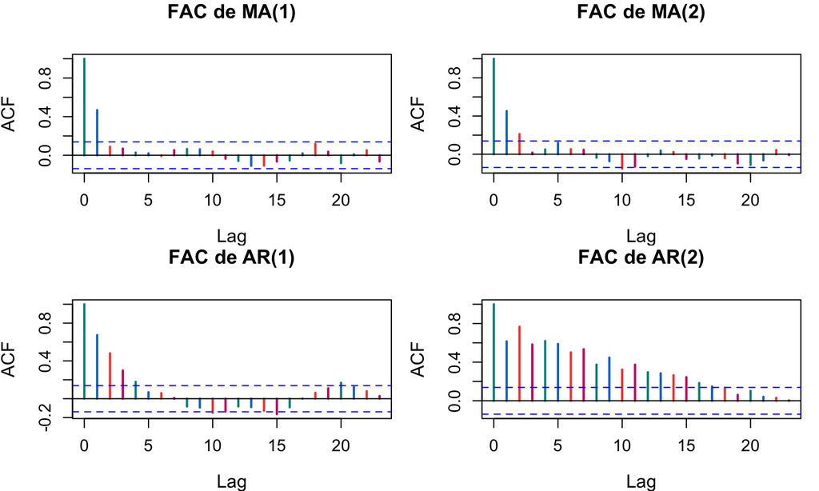

## Identificación del orden de un ARMA(\(p\),\(q\)) (3/8)

Regla 2

Si el modelo resulta ser un AR(\(p\)), la *función de autocorrelación parcial* nos indicará su orden.

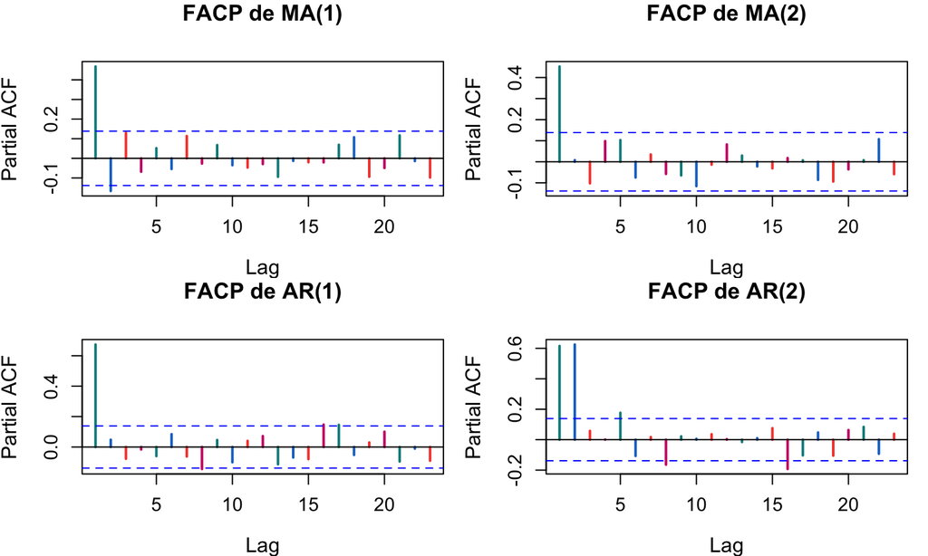

## Identificación del orden de un ARMA(\(p\),\(q\)) (4/8)

Regla 3

Los residuales del modelo seleccionado deben comportarse (estadísticamente) como un ruido blanco.

## Identificación del orden de un ARMA(\(p\),\(q\)) (5/8)

Para saber si el residual de un proceso se comporta (estadísticamente) como un ruido blanco, usamos el **estadístico Q** de *Ljung-Box*:

\[ Q_{LB} = T(T+2)\sum_{h=1}^m\frac{\rho_h^2}{T-h} \]

Probamos la hipótesis nula:

\[ \begin{align} H_0 :& \ \varepsilon_t \sim WN \\ H_1 :& \ \varepsilon_t \nsim WN \end{align} \]

Si la hipótesis nula es correcta, se puede demostrar que:

\[ Q_{LB} \sim \chi^2_m; \ m \approx \sqrt{T} \]

## Identificación del orden de un ARMA(\(p\),\(q\)) (6/8)

Regla 4

Si tenemos más de un modelo, podemos seleccionar el mejor usando la función de verosimilitud. En general, el modelo con un *valor más alto* para la función de (log) verosimilitud es el mejor.

Esto también nos ayuda a elegir el orden de un proceso ARMA(\(p,q\)) cuando \(p\) y \(q\) son simultáneamente diferentes de cero.

## Identificación del orden de un ARMA(\(p\),\(q\)) (7/8)

Alternativamente, podemos elegir el modelo comparando:

- Los valores del **criterio de información de Akaike** (AIC):

\[ AIC = \mathbb{E}[-2\mathcal{L}(\cdot)] = T\ln(s^2) + 2k \]

- Los valores del **criterio de información de Schwartz** (SIC o BIC):

\[ BIC = T\ln(s^2) + k\ln(T) \]

En general, buscamos el modelo que tenga el *menor valor posible* para estos criterios.

## Identificación del orden de un ARMA(\(p\),\(q\)) (8/8)

Regla 5

Si el AIC y el BIC seleccionan modelos diferentes, tomar en cuenta que:

- *AIC es eficiente*: selecciona el modelo que tenga el error de predicción más pequeño.
- *BIC es consistente*: selecciona el modelo correcto con probabilidad 1 si \(T\) es grande.

## Pronósticos

## Pronósticos usando ARMA(\(p\),\(q\)) (1/3)

Una vez que hemos estimado los coeficientes de un proceso ARMA(\(p\),\(q\)), podemos utilizar el modelo para realizar pronósticos.

Sea \(y_T\) el último valor disponible de \(y_t\). Entonces, el mejor pronóstico para \(h\) periodos hacia el futuro de \(y_t\), \(\widehat y_{T+h\mid T}, \ h=1,2,\dots\), es la **proyección lineal óptima**:

\[ \begin{align} \widehat y_{T+h\mid T} &= \mathbb{E}(y_{T+h}\mid \Omega_T),\\ \Omega_T&=\{y_T,y_{T-1},y_{T-2},\dots\} \end{align} \] la cual, *en el caso de normalidad*, coincide con el valor esperado condicional.

## Pronósticos usando ARMA(\(p\),\(q\)) (2/3)

Ejemplo

Consideremos un proceso AR(\(1\)):

\[ \begin{align} y_t&=\phi_0+\phi_1y_{t-1}+\varepsilon_t, \ |\phi_1|<1\\ \varepsilon_t & \sim iid\mathcal{N}(0,\sigma^2)\\ \end{align} \] En este caso tenemos:

\[ \begin{align} \mathbb{E}(y_{T+1}\mid\Omega_T) &= \phi_0 + \phi_1 y_T,\\ \mathbb{E}(y_{T+2}\mid\Omega_T) &= \phi_0 (1+\phi_1) + \phi_1^{2} y_T,\\ \mathbb{E}(y_{T+3}\mid\Omega_T) &= \phi_0(1+\phi_1+\phi_1^{2}) + \phi_1^{3} y_T,\\ & \vdots \\ \mathbb{E}(y_{T+h}\mid\Omega_T) &= \phi_0\sum_{j=0}^{h-1}\phi_1^{j} + \phi_1^{h} y_T\\ &= \mu(1-\phi_1^h)+\phi_1^h y_T \\ \end{align} \]

## Pronósticos usando ARMA(\(p\),\(q\)) (3/3)

Ejemplo (cont’d)

Nota que, para un proceso AR(\(1\)), si consideramos un horizonte más largo:

\[ \lim_{h\to\infty}\mathbb{E}(y_{T+h}\mid\Omega_T)=\mu, \]

donde:

\[ \mu=\frac{\phi_0}{1-\phi_1}. \] Esto es, \(\mathbb{E}(y_{T+h})\) *converge a la media no condicional* de \(y_t\).

## Varianza del pronóstico (1/2)

Por supuesto, la calidad del pronóstico \(y_{T+h}\) depende crucialmente de la **varianza del error del pronóstico**, \(\mathbb{V}ar\big[y_{T+h}-\mathbb{E}(y_{T+h}\mid\Omega_T)\big]\).

Ejemplo

Consideremos un proceso AR(\(1\)). La varianza del error de pronóstico de \(y_t\) para \(h\) periodos hacia el futuro es:

\[ \begin{align} \mathbb{V}ar\!\big[y_{T+h}-\mathbb{E}(y_{T+h}\mid\Omega_T)\big] &=\sigma^2\sum_{j=0}^{h-1}\phi_1^{2j} \\ &=\sigma^2\frac{1-\phi_1^{2h}}{1-\phi_1^2} \end{align} \]

## Varianza del pronóstico (2/2)

Nota que, conforme \(h\) crece, tenemos que la varianza del pronóstico *converge a la varianza no condicional* de \(y_t\):

\[ \lim_{h\to\infty}\mathbb{V}ar\!\big[y_{T+h}-\mathbb{E}(y_{T+h}\mid\Omega_T)\big] = \frac{\sigma^2}{1-\phi_1^2}. \]

## Pronósticos, caso general

Recordemos que, si un proceso ARMA(\(p,q\)) es estacionario e invertible, existe una representación MA(\(\infty\)) de la forma:

\[ y_t=\mu + \sum_{i=0}^{\infty}\psi_i\,\varepsilon_{t-i},\qquad \psi_0=1. \]

En este caso:

\[ \begin{align} \mathbb{V}ar\!\big[y_{T+h}-\mathbb{E}(y_{T+h}\mid\Omega_T)\big] &=\sigma^2\sum_{i=0}^{h-1}\psi_i^{2} \\ \lim_{h\to\infty}\mathbb{E}(y_{T+h}\mid\Omega_T)&=\mu\ . \end{align} \]

## Intervalos de predicción

Si \(\varepsilon_t\sim iid \mathcal{N}(0,\sigma^2)\), un intervalo de confianza de \(100(1-\alpha)\%\) para \(y_{T+h}\) se calcula como:

\[ \widehat y_{T+h\mid T}\ \pm\ z_{1-\alpha/2}\,\sqrt{\mathbb{V}ar\!\big[y_{T+h}-\mathbb{E}(y_{T+h}\mid\Omega_T)\big]}. \]

Por ejemplo, si \(\alpha=0.05\), \(z_{1-\alpha/2}=1.96\). Entonces:

\[ \widehat y_{T+h\mid T}\ \pm\ 1.96\,\sqrt{\mathbb{V}ar\!\big[y_{T+h}-\mathbb{E}(y_{T+h}\mid\Omega_T)\big]}. \]